# Government Types

Democracy and Dictatorship

The Democracy and Dictatorship (DD) data were released as part of TidyTuesday on November 5, 2024. TidyTuesday is a weekly project that shares open datasets for users to practice data analysis. This version updates the dataset from Bjørnskov and Rode (2020), building on earlier work by Cheibub et al. ([2010](https://doi.org/10.1007/s11127-009-9491-2)) and Alvarez et al. (1996). The dataset was later cleaned and shared on GitHub by Jon Harmon. Bjørnskov and Rode expanded existing data on political regimes by adding more countries, institutional detail, and a clear indicator for both successful and failed coups. They defined coups using three criteria: the goal must be to overthrow the executive, the actors must be connected to the state, and the event must last no longer than a week. This provides a consistent way to identify and compare regime changes. The data include the regime types of countries around the world between the years 1950 and 2020. Each observation (row) represents a country and year. The dataset focuses primarily on whether a country is democratic or not. Using this structure, we can study how often countries move away from democracy and how long those periods last which we call “spells.” Building on this, our analysis applies unique visualization techniques and survival analysis methods to examine the duration and hazard of non-democratic spells.

World Happiness Report

With the first World Happiness report released on April 1st of 2012 by the United Nations General Assembly, this report has now captured self-perception data on global happiness for a near-consecutive 13 years. Today, the survey is supported by the University of Oxford and Gallup and represents over 140 countries. The report was established by the United Nations with the purpose of “giv[ing] more importance to happiness and well-being in determining how to achieve and measure social and economic development” (World Happiness Report). Each year, more than 100,000 people take the survey and are asked a happiness ranking question that is translated into their native language.

World Bank Group

World Bank Group is a collection of internationally-operating organizations that aim to reduce global poverty through sustainable development and financing. Their operations and mission are highly data-driven, and they provide a breadth of open-source, global welfare data to the public via their API. Most datasets date back several decades, represent hundreds of countries, and vary on completeness. Datasets associated with their products and services (e.g., lending portfolios, asset management) are created and updated internally. Other global development data are sourced via World Bank partners, including governments, international agencies, regional development banks, donors, and others. We accessed country-level data on population, life-expectancy, and education-related variables.

Research Question 1: Non-Democratic Spells

How long does it take for countries that transition away from democracy to return to it and what factors influence this?

**World Map of Democracy**

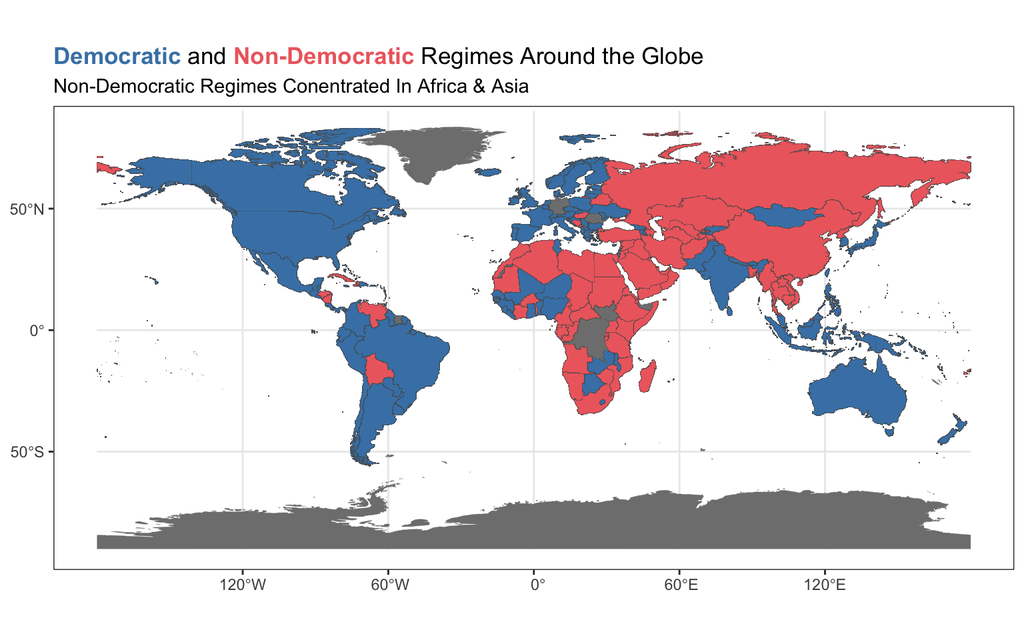

Fig 1. World map of democratic and non-democratic countries

Figure 1 shows countries’ regime types in the most recent year available, with democratic countries in blue and non-democratic countries in red. Non-democratic regimes are more concentrated in regions such as Africa, the Middle East, and Southeast Asia.

**Flow of Change in Regime Types**

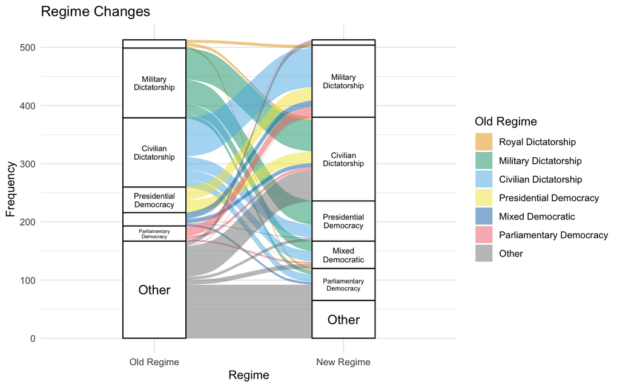

Fig 2. Sankey plot of regime changes from past to present (1950-2020)

Figure 2 presents a Sankey diagram of changes in political regime categories from 1950 to 2020, with flows colored by initial regime. Most transitions into democratic regimes originate from military or civilian dictatorship.

**Percent of Dictatorships Regimes by Country**

Table 1. Counts of regimes per country, with the percent of regimes that were dictatorships

| Country | Number of Regimes | Percent Dictatorship |
| --- | --- | --- |
| Thailand | 10 | 60.00% |
| Argentina | 9 | 44.44% |
| Bangladesh | 9 | 66.67% |
| Burundi | 9 | 66.67% |
| Guinea-Bissau | 9 | 66.67% |
| Pakistan | 9 | 55.56% |
| Anguilla | 8 | 0.00% |
| Bolivia | 8 | 75.00% |
| Cambodia | 8 | 100.00% |
| Ghana | 8 | 37.50% |
| Honduras | 8 | 62.50% |
| Lebanon | 8 | 87.50% |
| Niger | 8 | 50.00% |
| Peru | 8 | 50.00% |
| Sudan | 8 | 50.00% |
| Central African Republic | 7 | 71.43% |
| Comoros | 7 | 57.14% |
| Ecuador | 7 | 57.14% |
| Fiji | 7 | 71.43% |
| Guatemala | 7 | 42.86% |
| Guyana | 7 | 28.57% |
| Maldives | 7 | 42.86% |
| Sierra Leone | 7 | 57.14% |
| Turks and Caicos | 7 | 0.00% |
| Uganda | 7 | 71.43% |
| Benin | 6 | 66.67% |
| Congo, Republic of | 6 | 50.00% |
| Grenada | 6 | 16.67% |
| Laos | 6 | 83.33% |
| Lesotho | 6 | 50.00% |

[output cut: 178 more lines]

Table 1 summarizes the number of regime types by country and the percentage classified as dictatorships over the 1950-2020 period, noting that data may be incomplete for some countries. Countries with a larger number of regimes show wide variation in dictatorship prevalence, ranging from 0% to 100%.

**Governance Types by World Region**

Table 2. Percent of observations under each form of governance, by World Region

| World Region | Number of Observations | Governance Type (%) Percent Democratic | Governance Type (%) Percent Presidential | Governance Type (%) Percent Monarchy | Governance Type (%) Percent Commonwealth | Governance Type (%) Percent Colony | Governance Type (%) Percent Communist |
| --- | --- | --- | --- | --- | --- | --- | --- |
| East Asia & Pacific | 2,556 | 44.25% | 30.83% | 29.58% | 26.84% | 24.96% | 11.62% |
| Europe & Central Asia | 3,621 | 56.84% | 28.11% | 21.84% | 3.62% | 2.26% | 32.75% |
| Latin America & Caribbean | 2,982 | 76.46% | 55.06% | 35.71% | 19.28% | 32.13% | 3.12% |
| Middle East & North Africa | 1,420 | 12.39% | 33.87% | 46.06% | 3.94% | 7.96% | 0.00% |
| North America | 213 | 93.90% | 33.33% | 66.67% | 33.33% | 33.33% | 0.00% |
| South Asia | 568 | 41.37% | 29.75% | 29.40% | 48.42% | 2.82% | 2.46% |
| Sub-Saharan Africa | 3,408 | 18.37% | 67.78% | 6.31% | 26.91% | 19.42% | 5.96% |

Table 2 summarizes the percentage of country-year observations classified under each form of governance. Note that these categories are not mutually exclusive as a country call fall into multiple forms at once (e.g., a country can be both democratic and presidential).

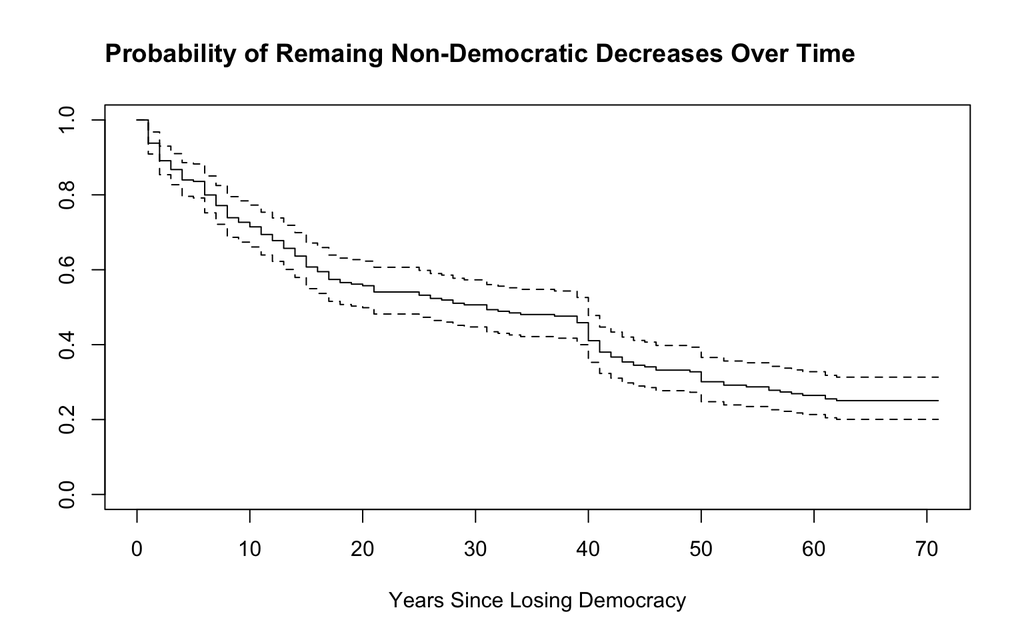

Cox Proportional Hazards Model Coefficent Estimates

| **Characteristic** | **HR** | **95% CI** | **p-value** |
| --- | --- | --- | --- |
| Region |  |  |  |
| East Asia & Pacific | — | — |  |
| Europe & Central Asia | 2.67 | 1.23, 5.78 | 0.013 |
| Latin America & Caribbean | 3.31 | 2.08, 5.26 | <0.001 |
| Middle East & North Africa | 0.04 | 0.00, 0.26 | 0.001 |
| North America | 3.20 | 0.43, 23.8 | 0.3 |
| South Asia | 1.52 | 0.77, 2.98 | 0.2 |
| Sub-Saharan Africa | 0.88 | 0.56, 1.39 | 0.6 |
| Communist |  |  |  |
| FALSE | — | — |  |
| TRUE | 0.22 | 0.10, 0.50 | <0.001 |
| Multiparty System |  |  |  |
| FALSE | — | — |  |
| TRUE | 0.87 | 0.63, 1.21 | 0.4 |

Abbreviations: CI = Confidence Interval, HR = Hazard Ratio

There are 255 non-democratic spells, 178 of which return to democracy. The Cox Proportional Hazards Model significantly predicts “time to democracy” (p < 2e-16)

**Hazard Ratio Interpretations:**

- Countries in Europe & Central Asia return to democracy about **2.67 times faster** than the baseline region, East Asia & Pacific (p = 0.013).
- Countries in Latin America & the Caribbean return to democracy about **3.31 times faster** than the baseline region, East Asia & Pacific (p < 0.001).
- Countries in the Middle East & North Africa are about **96.4% less likely** to return to democracy than the baseline region, East Asia & Pacific (p = 0.001).
- Communist regimes are about **78% less likely** to return to democracy compared to non-communist regimes (p < 0.001).
- There is insufficient evidence to conclude that multiparty systems affect the likelihood of a non-democratic regime returning to democracy (p = 0.42).

Research Question 2: Global Welfare & Regimes

How do welfare indicators (e.g., population, happiness, life expectancy) differ across political regimes?

**Life Expectancy by Regime Type**

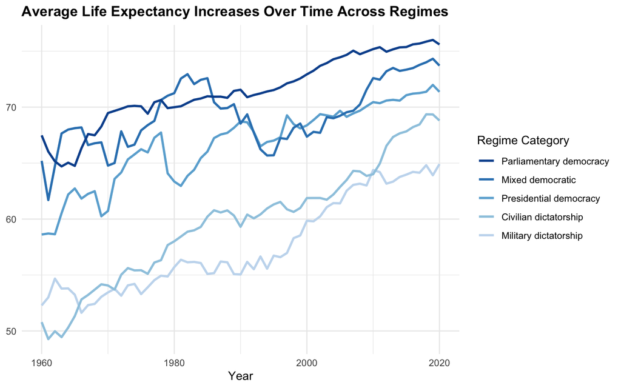

Fig 4. Life graph of life expectancy by regime over time

Figure 4 shows that life expectancy generally increases over time across all regime types. More democratic regimes tend to have higher average life expectancy compared to less democratic ones across all time.

**Democratic Principles for Top Regimes**

Table 3. Percent of observations demonstrating democratic principles, by regime category

| Regime | Number of Observations | Democratic Principles Represented (% Observations) Democratic | Democratic Principles Represented (% Observations) Full Voting Rights | Democratic Principles Represented (% Observations) Multi-Party Elections | Democratic Principles Represented (% Observations) Free & Fair Elections | Democratic Principles Represented (% Observations) Rotating Top Office |
| --- | --- | --- | --- | --- | --- | --- |
| Civilian dictatorship | 2,998 | 0.03% | 93.70% | 52.43% | 3.14% | 0.47% |
| Military dictatorship | 1,892 | 0.05% | 90.91% | 40.12% | 0.26% | 0.05% |
| Parliamentary democracy | 2,660 | 99.89% | 97.26% | 99.89% | 99.89% | 99.89% |
| Presidential democracy | 1,509 | 99.87% | 92.05% | 99.87% | 99.87% | 99.67% |

Table 3 shows the percentage of country-year observations that exhibit each of the five democratic principles. Parliamentary and presidential democracies have high percentages across all principles. In contrast, civilian and military dictatorships rarely meet this criteria, with the exception of full voting rights, which appears relatively more common.

**Happiness by Regime Type**

Table 4. Happiness Score Summary by Regime Category

| Regime | Number of Observations | Average Happiness Score | Standard Deviation Happiness Score | Minimum Happiness Score | Median Happiness Score | Maximum Happiness Score |
| --- | --- | --- | --- | --- | --- | --- |
| Parliamentary democracy | 181 | 6.26 | 0.98 | 3.57 | 6.31 | 7.69 |
| Royal dictatorship | 41 | 6.05 | 0.63 | 4.63 | 6.23 | 7.14 |
| Presidential democracy | 177 | 5.68 | 1.02 | 3.41 | 5.80 | 7.65 |
| Mixed democratic | 130 | 5.61 | 1.10 | 3.48 | 5.44 | 7.81 |
| Civilian dictatorship | 210 | 4.92 | 0.82 | 2.57 | 5.00 | 7.34 |
| Military dictatorship | 58 | 3.96 | 0.85 | 2.69 | 3.71 | 6.47 |

Happiness Score scraped from World Happiness Report Wikipedia page, Scores are out of 10

Table 4 shows that military and civilian dictatorships tend to have lower reported happiness, whereas parliamentary democracies and royal dictatorships tend to have higher reported happiness.